# Отток клиентов

Из банка стали уходить клиенты. Банковские маркетологи посчитали: сохранять текущих клиентов дешевле, чем привлекать новых.

Нужно спрогнозировать, уйдёт клиент из банка в ближайшее время или нет. Нам предоставлены исторические данные о поведении клиентов и расторжении договоров с банком.

Необходимо построить модель с предельно большим значением *F1*-меры. Для успешного выполнения задачи, нужно довести метрику до 0.59.

Дополнительно измерим *AUC-ROC*, сравним её значение с *F1*-мерой.

Источник данных: https://www.kaggle.com/barelydedicated/bank-customer-churn-modeling

Цель исследования — спрогнозировать, уйдёт клиент из банка в ближайшее время или нет и найти модель с предельно большим значением F1-меры (не меньше 0.59)

Данные о поведении клиентов получим из файла *Churn.csv*. В нем представлены исторические данные о поведении клиентов и расторжении договоров с банком

Исследование пройдёт в четыре этапа:

- Подготовка данных
- Исследование задачи
- Борьба с дисбалансом
- Тестирование модели

## Подготовка данных

```python
import pandas as pd
import matplotlib.pyplot as plt

from sklearn.model_selection import train_test_split
from sklearn.preprocessing import StandardScaler
from sklearn.utils import shuffle

from sklearn.linear_model import LogisticRegression
from sklearn.tree import DecisionTreeClassifier
from sklearn.ensemble import RandomForestClassifier

from sklearn.metrics import f1_score, roc_auc_score, confusion_matrix, roc_curve


r_state = 12345

data = pd.read_csv('datasets/Churn.csv')
```

### Изучим данные

```python
data.info()
display(data.sample(5, random_state=r_state))

print('Количество пропусков по столбцам:')
print()

for col in data.columns:
    nmv = data[col].isna().sum()
    pmv = nmv/len(data)
    print('{} - {} шт. - {}%'.format(col, nmv, round(pmv*100, 2)))

print()
print('Количество явных дубликатов:', data.duplicated().sum())
```

```
<class 'pandas.core.frame.DataFrame'>
RangeIndex: 10000 entries, 0 to 9999
Data columns (total 14 columns):
 #   Column           Non-Null Count  Dtype
---  ------           --------------  -----
 0   RowNumber        10000 non-null  int64
 1   CustomerId       10000 non-null  int64
 2   Surname          10000 non-null  object
 3   CreditScore      10000 non-null  int64
 4   Geography        10000 non-null  object
 5   Gender           10000 non-null  object
 6   Age              10000 non-null  int64
 7   Tenure           9091 non-null   float64
 8   Balance          10000 non-null  float64
 9   NumOfProducts    10000 non-null  int64
 10  HasCrCard        10000 non-null  int64
 11  IsActiveMember   10000 non-null  int64
 12  EstimatedSalary  10000 non-null  float64
 13  Exited           10000 non-null  int64
dtypes: float64(3), int64(8), object(3)
memory usage: 1.1+ MB
```

|  | RowNumber | CustomerId | Surname | CreditScore | Geography | Gender | Age | Tenure | Balance | NumOfProducts | HasCrCard | IsActiveMember | EstimatedSalary | Exited |
| --- | --- | --- | --- | --- | --- | --- | --- | --- | --- | --- | --- | --- | --- | --- |
| 7867 | 7868 | 15697201 | Yocum | 640 | Spain | Female | 46 | 3.0 | 0.00 | 1 | 1 | 1 | 156260.08 | 0 |
| 1402 | 1403 | 15613282 | Vorobyova | 757 | France | Male | 29 | 8.0 | 130306.49 | 1 | 1 | 0 | 77469.38 | 0 |
| 8606 | 8607 | 15694581 | Rawlings | 807 | Spain | Male | 42 | 5.0 | 0.00 | 2 | 1 | 1 | 74900.90 | 0 |
| 8885 | 8886 | 15815125 | Michael | 668 | Spain | Male | 45 | 4.0 | 102486.21 | 2 | 1 | 1 | 158379.25 | 0 |
| 6494 | 6495 | 15752846 | Pinto | 699 | France | Male | 28 | 7.0 | 0.00 | 2 | 1 | 1 | 22684.78 | 0 |

```
Количество пропусков по столбцам:

RowNumber - 0 шт. - 0.0%
CustomerId - 0 шт. - 0.0%
Surname - 0 шт. - 0.0%
CreditScore - 0 шт. - 0.0%
Geography - 0 шт. - 0.0%
Gender - 0 шт. - 0.0%
Age - 0 шт. - 0.0%
Tenure - 909 шт. - 9.09%
Balance - 0 шт. - 0.0%
NumOfProducts - 0 шт. - 0.0%
HasCrCard - 0 шт. - 0.0%
IsActiveMember - 0 шт. - 0.0%
EstimatedSalary - 0 шт. - 0.0%
Exited - 0 шт. - 0.0%

Количество явных дубликатов: 0
```

Признаки

- RowNumber — индекс строки в данных
- CustomerId — уникальный идентификатор клиента
- Surname — фамилия
- CreditScore — кредитный рейтинг
- Geography — страна проживания
- Gender — пол
- Age — возраст
- Tenure — сколько лет человек является клиентом банка
- Balance — баланс на счёте
- NumOfProducts — количество продуктов банка, используемых клиентом
- HasCrCard — наличие кредитной карты
- IsActiveMember — активность клиента
- EstimatedSalary — предполагаемая зарплата

Целевой признак

- Exited — факт ухода клиента
- Данные состоят из 10000 объектов
- Данные имеют 14 признаков (1 целевой и 13 вспомогательных)
- Явные дубликаты отсутствуют
- Данные в признаке "Tenure" обозначают количество лет, переведем их в формат целого числа (int)
- Пропущенные значения есть в признаке "Tenure" - 909 шт. - 9.09%
  - Заменяя пропущенные значения средним или медианным есть риск повлиять на обучение модели
  - Удалим пропущенные значения
- Признаки "RowNumber", "CustomerId" и "Surname" ни как не влияют на вероятность ухода клиента, но могут усложнить обучение модели
  - Удалим данные признаки

```python
data=data.dropna(subset=['Tenure'])
data['Tenure'] = data['Tenure'].astype(int)
data = data.drop(['RowNumber', 'CustomerId', 'Surname'], axis=1)
```

### Изучим подробнее каждый признак и проверим на аномалии

#### CreditScore — кредитный рейтинг

```python
print("Минимальное значение кредитного рейтинга:", data['CreditScore'].min())
print("Максимальное значение кредитного рейтинга:", data['CreditScore'].max())
```

```
Минимальное значение кредитного рейтинга: 350
Максимальное значение кредитного рейтинга: 850
```

Аномалий не обнаружено

#### Geography — страна проживания

```python
data['Geography'].value_counts()
```

```
France     4550
Germany    2293
Spain      2248
Name: Geography, dtype: int64
```

Аномалий не обнаружено

#### Gender — пол

```python
data['Gender'].value_counts()
```

```
Male      4974
Female    4117
Name: Gender, dtype: int64
```

Аномалий не обнаружено

#### Age — возраст

```python
print("Минимальный возраст клиента:", data['Age'].min())
print("Максимальный возраст клиента:", data['Age'].max())
```

```
Минимальный возраст клиента: 18
Максимальный возраст клиента: 92
```

Аномалий не обнаружено

#### Tenure — сколько лет человек является клиентом банка

```python
data['Tenure'].value_counts()
```

```
1     952
2     950
8     933
3     928
5     927
7     925
4     885
9     882
6     881
10    446
0     382
Name: Tenure, dtype: int64
```

Аномалий не обнаружено

#### Balance — баланс на счёте

```python
print("Минимальный баланс на счёте:", data['Balance'].min())
print("Максимальный баланс на счёте:", data['Balance'].max())
print("Количество клиентов с нулевым балансом:", len(data.loc[data['Balance']==0]))
```

```
Минимальный баланс на счёте: 0.0
Максимальный баланс на счёте: 250898.09
Количество клиентов с нулевым балансом: 3283
```

Аномалий не обнаружено

#### NumOfProducts — количество продуктов банка, используемых клиентом

```python
data['NumOfProducts'].value_counts()
```

```
1    4617
2    4184
3     234
4      56
Name: NumOfProducts, dtype: int64
```

Аномалий не обнаружено

#### HasCrCard — наличие кредитной карты

```python
data['HasCrCard'].value_counts()
```

```
1    6409
0    2682
Name: HasCrCard, dtype: int64
```

Аномалий не обнаружено

#### IsActiveMember — активность клиента

```python
data['IsActiveMember'].value_counts()
```

```
1    4687
0    4404
Name: IsActiveMember, dtype: int64
```

Аномалий не обнаружено

#### EstimatedSalary — предполагаемая зарплата

```python
print("Минимальная предполагаемая зарплата:", data['EstimatedSalary'].min())
print("Максимальная предполагаемая зарплата:", data['EstimatedSalary'].max())
```

```
Минимальная предполагаемая зарплата: 11.58
Максимальная предполагаемая зарплата: 199992.48
```

Аномалий не обнаружено

#### Exited — факт ухода клиента

```python
data['Exited'].value_counts()
```

```
0    7237
1    1854
Name: Exited, dtype: int64
```

Аномалий не обнаружено

### Подготовим данные

Преобразуем данные методом OHE, чтобы исключить попадание в дамми-ловушку

```python
data = pd.get_dummies(data, drop_first=True)
display(data.sample(5, random_state=r_state))
```

|  | CreditScore | Age | Tenure | Balance | NumOfProducts | HasCrCard | IsActiveMember | EstimatedSalary | Exited | Geography_Germany | Geography_Spain | Gender_Male |
| --- | --- | --- | --- | --- | --- | --- | --- | --- | --- | --- | --- | --- |
| 862 | 725 | 41 | 7 | 113980.21 | 1 | 1 | 1 | 116704.25 | 0 | 0 | 0 | 1 |
| 9727 | 530 | 45 | 1 | 0.00 | 1 | 0 | 1 | 190663.89 | 1 | 0 | 0 | 0 |
| 1717 | 707 | 35 | 3 | 56674.48 | 1 | 1 | 0 | 17987.40 | 1 | 0 | 1 | 0 |
| 8640 | 730 | 32 | 9 | 127661.69 | 1 | 0 | 0 | 60905.51 | 0 | 0 | 0 | 0 |
| 5288 | 582 | 30 | 2 | 0.00 | 2 | 1 | 1 | 132029.95 | 0 | 0 | 0 | 1 |

Определим целевой и вспомогательные признаки

```python
features = data.drop(['Exited'], axis=1)
target = data['Exited']
```

Отделим обучающие данные

```python
features_train, features_valid, target_train, target_valid = train_test_split(
    features, target, test_size=0.4, random_state=r_state, stratify=target)
```

Разделим оставшиеся данные на валидационную и тестовую выборки

```python
features_valid, features_test, target_valid, target_test = train_test_split(
    features_valid, target_valid, test_size=0.5, random_state=r_state, stratify=target_valid)
```

Проверим правильность разделения выборок

```python
features = {'features_train' : features_train, 'features_valid' : features_valid, 'features_test' : features_test}
targets = {'target_train' : target_train, 'target_valid' : target_valid, 'target_test' : target_test}

print('Вспомогательные признаки:')
print()
for i in features:
    sh = features[i].shape
    psh = sh[0]/len(data)
    print('{} - Объектов: {} шт., признаков: {} шт. - {}%'.format(i, sh[0], sh[1], round(psh*100, 2)))

print()

print('Целевые признаки:')
print()
for i in targets:
    sh = targets[i].shape
    psh = sh[0]/len(data)
    print('{} - Объектов: {} шт. - {}%'.format(i, sh[0], round(psh*100, 2)))
```

```
Вспомогательные признаки:

features_train - Объектов: 5454 шт., признаков: 11 шт. - 59.99%
features_valid - Объектов: 1818 шт., признаков: 11 шт. - 20.0%
features_test - Объектов: 1819 шт., признаков: 11 шт. - 20.01%

Целевые признаки:

target_train - Объектов: 5454 шт. - 59.99%
target_valid - Объектов: 1818 шт. - 20.0%
target_test - Объектов: 1819 шт. - 20.01%
```

Стандартизируем численные признаки в выборках, так как в данных присутствуют значения в разных масштабах

```python
numeric = ['CreditScore', 'Age', 'Tenure', 'Balance', 'NumOfProducts', 'EstimatedSalary']

scaler = StandardScaler()
scaler.fit(features_train[numeric])
```

```
StandardScaler()
```

```python
features_train[numeric] = scaler.transform(features_train[numeric])
display(features_train.sample(5, random_state=r_state))
```

|  | CreditScore | Age | Tenure | Balance | NumOfProducts | HasCrCard | IsActiveMember | EstimatedSalary | Geography_Germany | Geography_Spain | Gender_Male |
| --- | --- | --- | --- | --- | --- | --- | --- | --- | --- | --- | --- |
| 5329 | -0.313795 | 0.202723 | -0.705222 | -1.222967 | 0.789359 | 1 | 1 | 0.654508 | 0 | 0 | 1 |
| 8279 | -0.470035 | -0.468939 | -1.053112 | -1.222967 | -0.910943 | 0 | 0 | -1.106494 | 0 | 0 | 0 |
| 8495 | 0.477820 | 0.298675 | -0.357331 | -1.222967 | -0.910943 | 0 | 0 | 0.464100 | 0 | 0 | 1 |
| 1639 | -1.522050 | -0.660843 | 1.034232 | 1.502997 | 0.789359 | 0 | 1 | -1.459704 | 1 | 0 | 1 |
| 9993 | -0.063812 | -1.044650 | 0.686341 | 1.259187 | -0.910943 | 1 | 0 | -1.224724 | 0 | 0 | 1 |

```python
features_valid[numeric] = scaler.transform(features_valid[numeric])
display(features_valid.sample(5, random_state=r_state))
```

|  | CreditScore | Age | Tenure | Balance | NumOfProducts | HasCrCard | IsActiveMember | EstimatedSalary | Geography_Germany | Geography_Spain | Gender_Male |
| --- | --- | --- | --- | --- | --- | --- | --- | --- | --- | --- | --- |
| 2556 | -0.167972 | 0.202723 | -0.357331 | -1.222967 | 0.789359 | 1 | 1 | 1.127936 | 0 | 1 | 0 |
| 7905 | 0.529899 | -0.372988 | 1.730013 | 1.333359 | 0.789359 | 1 | 1 | -0.494889 | 0 | 1 | 1 |
| 6219 | -0.147140 | -0.181084 | -1.401003 | 0.620111 | -0.910943 | 1 | 0 | -0.819705 | 0 | 1 | 1 |
| 3110 | -1.084578 | 3.369132 | 1.034232 | 0.616133 | 0.789359 | 1 | 1 | -0.572072 | 1 | 0 | 0 |
| 5392 | 0.915291 | 0.490579 | -1.053112 | -1.222967 | 0.789359 | 1 | 0 | -0.984205 | 0 | 1 | 1 |

```python
features_test[numeric] = scaler.transform(features_test[numeric])
display(features_test.sample(5, random_state=r_state))
```

|  | CreditScore | Age | Tenure | Balance | NumOfProducts | HasCrCard | IsActiveMember | EstimatedSalary | Geography_Germany | Geography_Spain | Gender_Male |
| --- | --- | --- | --- | --- | --- | --- | --- | --- | --- | --- | --- |
| 7239 | -0.730435 | 0.586530 | 1.034232 | 0.437686 | -0.910943 | 1 | 0 | -0.907563 | 1 | 0 | 1 |
| 5574 | -1.532466 | -0.277036 | 1.382122 | -1.222967 | 0.789359 | 1 | 1 | -1.449003 | 0 | 1 | 0 |
| 8895 | 0.509067 | 0.106771 | 1.034232 | 0.730581 | -0.910943 | 1 | 0 | 0.042339 | 0 | 0 | 0 |
| 2299 | -0.001316 | -1.332505 | -1.053112 | 0.607204 | -0.910943 | 1 | 1 | -1.291712 | 1 | 0 | 0 |
| 5105 | 0.217420 | 1.162241 | -0.705222 | 0.328039 | -0.910943 | 1 | 0 | 1.333945 | 1 | 0 | 1 |

## Исследование задачи

### Проверим баланс классов в целевом признаке

```
Соотношение оставшихся и ушедших клиентов:
79.6% / 20.4%
```

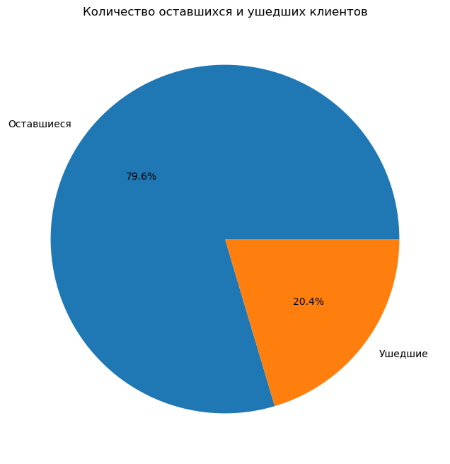

```python
p_exited_0 = data['Exited'][data['Exited'] == 0].count()/len(data['Exited'])
p_exited_1 = data['Exited'][data['Exited'] == 1].count()/len(data['Exited'])
print('Соотношение оставшихся и ушедших клиентов:', )
print('{}% / {}%'.format(round(p_exited_0*100, 1), round(p_exited_1*100, 1)))
print()

data['Exited'].value_counts().plot(kind='pie', title='Количество оставшихся и ушедших клиентов', figsize=(8,8),
                                   legend=False, label='', autopct='%1.1f%%', labels = ['Оставшиеся','Ушедшие']);
```

Соотношение "ушедших" к "оставшимся" примерно 1 к 4. В данных имеется дисбаланс

Проверим баланс классов по выборкам

```python
for i in targets:
    p_exited_0 = targets[i][targets[i] == 0].count()/len(targets[i])
    p_exited_1 = targets[i][targets[i] == 1].count()/len(targets[i])
    print('Соотношение оставшихся и ушедших клиентов в выборке {}:'.format(i))
    print('{}% / {}%'.format(round(p_exited_0*100, 1), round(p_exited_1*100, 1)))
    print()
```

```
Соотношение оставшихся и ушедших клиентов в выборке target_train:
79.6% / 20.4%

Соотношение оставшихся и ушедших клиентов в выборке target_valid:
79.6% / 20.4%

Соотношение оставшихся и ушедших клиентов в выборке target_test:
79.6% / 20.4%
```

Выборки разделены равномерно

### Обучим модель без учёта дисбаланса

В нашем исследовании целевой признак - столбец "Exited" (категориальный). Категорий в данном признаке две (ушел или не ушел клиент), соответственно нам предстоит решить задачу бинарной (двоичной) классификации.

Для решения данной задачи используем 3 модели:

Decision Tree (Дерево решений) Random Forest (Случайный лес) Logistic Regression (Логистическая регрессия) Применим все 3 модели, подберем им оптимальные гиперпараметры и найдем лучший результат

Для проверки качества на разных моделях создадим функцию с метриками F1 и AUC-ROC:

```python
def test_f1_aucroc(model):
    predictions_valid = model.predict(features_valid)
    probabilities_valid = model.predict_proba(features_valid)
    probabilities_one_valid = probabilities_valid[:, 1]
    return f1_score(target_valid, predictions_valid), roc_auc_score(target_valid, probabilities_one_valid)
```

#### Decision Tree (Дерево решений)

```python
best_f1_DT = 0
best_aucroc_DT = 0
best_depth_DT = 0


for depth in range(1, 21):
    model_decision_tree = DecisionTreeClassifier(random_state=r_state, max_depth=depth)
    model_decision_tree.fit(features_train, target_train)
    f1, aucroc = test_f1_aucroc(model_decision_tree)
    print('Глубина =', depth, ', F1-мера =', f1, ', AUC-ROC =', aucroc)
    if ((f1 > best_f1_DT) and (aucroc > best_aucroc_DT)):
        best_f1_DT = f1
        best_aucroc_DT = aucroc
        best_depth_DT = depth

print()
print('Лучший результат:')
print('Глубина =', best_depth_DT, ', F1-мера =', best_f1_DT, ', AUC-ROC =', best_aucroc_DT)
```

```
Глубина = 1 , F1-мера = 0.0 , AUC-ROC = 0.6743788151710854
Глубина = 2 , F1-мера = 0.5240464344941957 , AUC-ROC = 0.7304023381398823
Глубина = 3 , F1-мера = 0.5208681135225375 , AUC-ROC = 0.7871290540704161
Глубина = 4 , F1-мера = 0.5127272727272727 , AUC-ROC = 0.8113524216847945
Глубина = 5 , F1-мера = 0.5733788395904437 , AUC-ROC = 0.8450470068195747
Глубина = 6 , F1-мера = 0.5797598627787307 , AUC-ROC = 0.8372802172726544
Глубина = 7 , F1-мера = 0.5815126050420169 , AUC-ROC = 0.8245379882534177
Глубина = 8 , F1-мера = 0.5463576158940396 , AUC-ROC = 0.806618209996703
Глубина = 9 , F1-мера = 0.5382059800664452 , AUC-ROC = 0.7900899155609618
Глубина = 10 , F1-мера = 0.5486443381180223 , AUC-ROC = 0.7564260660125885
Глубина = 11 , F1-мера = 0.5214814814814815 , AUC-ROC = 0.7171525062542261
Глубина = 12 , F1-мера = 0.5007541478129715 , AUC-ROC = 0.6987716942014057
Глубина = 13 , F1-мера = 0.5021770682148041 , AUC-ROC = 0.685568431386063
Глубина = 14 , F1-мера = 0.4921316165951359 , AUC-ROC = 0.6732369415669934
Глубина = 15 , F1-мера = 0.49108367626886146 , AUC-ROC = 0.6761139787309742
Глубина = 16 , F1-мера = 0.4918918918918919 , AUC-ROC = 0.675929565212532
Глубина = 17 , F1-мера = 0.5040431266846361 , AUC-ROC = 0.6809227009315678
Глубина = 18 , F1-мера = 0.4823989569752281 , AUC-ROC = 0.6752803923723588
Глубина = 19 , F1-мера = 0.48339973439575035 , AUC-ROC = 0.6750857336584475
Глубина = 20 , F1-мера = 0.48412698412698413 , AUC-ROC = 0.6749050456656304

Лучший результат:
Глубина = 5 , F1-мера = 0.5733788395904437 , AUC-ROC = 0.8450470068195747
```

#### Random Forest (Случайный лес)

```python
best_f1_RF = 0
best_aucroc_RF = 0
best_est_RF = 0
best_depth_RF = 0

for est in range(10, 51, 10):
    for depth in range(1, 21):
        model_random_forest = RandomForestClassifier(random_state=r_state, n_estimators=est, max_depth=depth)
        model_random_forest.fit(features_train, target_train)
        f1, aucroc = test_f1_aucroc(model_random_forest)
        print('Количество деревьев =', est,', глубина =', depth, ', F1-мера =', f1, ', AUC-ROC =', aucroc)
        if ((f1 > best_f1_RF) and (aucroc > best_aucroc_RF)):
            best_f1_RF = f1
            best_aucroc_RF = aucroc
            best_est_RF = est
            best_depth_RF = depth

print()
print('Лучший результат:')
print('Количество деревьев =', best_est_RF,', глубина =', best_depth_RF, ', F1-мера =', best_f1_RF,
      ', AUC-ROC =', best_aucroc_RF)
```

```
Количество деревьев = 10 , глубина = 1 , F1-мера = 0.0 , AUC-ROC = 0.8003043754435705
Количество деревьев = 10 , глубина = 2 , F1-мера = 0.20192307692307693 , AUC-ROC = 0.8213684973278667
Количество деревьев = 10 , глубина = 3 , F1-мера = 0.23584905660377362 , AUC-ROC = 0.8418588882658982
Количество деревьев = 10 , глубина = 4 , F1-мера = 0.4921875 , AUC-ROC = 0.8527458055238368
Количество деревьев = 10 , глубина = 5 , F1-мера = 0.5265151515151515 , AUC-ROC = 0.8672278550099937
Количество деревьев = 10 , глубина = 6 , F1-мера = 0.5369369369369369 , AUC-ROC = 0.8613443186665599
Количество деревьев = 10 , глубина = 7 , F1-мера = 0.5581395348837209 , AUC-ROC = 0.8678323215426658
Количество деревьев = 10 , глубина = 8 , F1-мера = 0.5748709122203098 , AUC-ROC = 0.8692843451550472
Количество деревьев = 10 , глубина = 9 , F1-мера = 0.5783132530120482 , AUC-ROC = 0.8754798942695828
Количество деревьев = 10 , глубина = 10 , F1-мера = 0.554006968641115 , AUC-ROC = 0.8574241343275519
Количество деревьев = 10 , глубина = 11 , F1-мера = 0.5884297520661157 , AUC-ROC = 0.8609400991362368
Количество деревьев = 10 , глубина = 12 , F1-мера = 0.5878378378378378 , AUC-ROC = 0.854859109934673
Количество деревьев = 10 , глубина = 13 , F1-мера = 0.5884297520661157 , AUC-ROC = 0.8584803208422669
Количество деревьев = 10 , глубина = 14 , F1-мера = 0.5794701986754967 , AUC-ROC = 0.8446893563595652
Количество деревьев = 10 , глубина = 15 , F1-мера = 0.5874799357945426 , AUC-ROC = 0.8426701214707629
Количество деревьев = 10 , глубина = 16 , F1-мера = 0.5557404326123129 , AUC-ROC = 0.8497942578473541
Количество деревьев = 10 , глубина = 17 , F1-мера = 0.546979865771812 , AUC-ROC = 0.8462242729171052
Количество деревьев = 10 , глубина = 18 , F1-мера = 0.5747899159663865 , AUC-ROC = 0.8537237560004247
Количество деревьев = 10 , глубина = 19 , F1-мера = 0.563758389261745 , AUC-ROC = 0.8402978930289826
Количество деревьев = 10 , глубина = 20 , F1-мера = 0.5888157894736843 , AUC-ROC = 0.84857787373076
Количество деревьев = 20 , глубина = 1 , F1-мера = 0.0 , AUC-ROC = 0.8133865586760972
Количество деревьев = 20 , глубина = 2 , F1-мера = 0.14962593516209474 , AUC-ROC = 0.8221340928438241
Количество деревьев = 20 , глубина = 3 , F1-мера = 0.21904761904761902 , AUC-ROC = 0.8452044102772349
Количество деревьев = 20 , глубина = 4 , F1-мера = 0.4543610547667342 , AUC-ROC = 0.858304289756481
Количество деревьев = 20 , глубина = 5 , F1-мера = 0.5431192660550459 , AUC-ROC = 0.8683017377714278
Количество деревьев = 20 , глубина = 6 , F1-мера = 0.5454545454545454 , AUC-ROC = 0.8669931468956127
Количество деревьев = 20 , глубина = 7 , F1-мера = 0.5549738219895287 , AUC-ROC = 0.8718298105383943
Количество деревьев = 20 , глубина = 8 , F1-мера = 0.5884353741496599 , AUC-ROC = 0.8718568205991762
Количество деревьев = 20 , глубина = 9 , F1-мера = 0.5983193277310924 , AUC-ROC = 0.8755190122886461
Количество деревьев = 20 , глубина = 10 , F1-мера = 0.5773195876288659 , AUC-ROC = 0.8709626944491531
Количество деревьев = 20 , глубина = 11 , F1-мера = 0.5902192242833052 , AUC-ROC = 0.8699866067353778
Количество деревьев = 20 , глубина = 12 , F1-мера = 0.5728643216080402 , AUC-ROC = 0.864063020991474
Количество деревьев = 20 , глубина = 13 , F1-мера = 0.5960264900662251 , AUC-ROC = 0.868475906094401
Количество деревьев = 20 , глубина = 14 , F1-мера = 0.6009852216748769 , AUC-ROC = 0.8637482140761534
Количество деревьев = 20 , глубина = 15 , F1-мера = 0.6089743589743591 , AUC-ROC = 0.8639624317995965
Количество деревьев = 20 , глубина = 16 , F1-мера = 0.5809682804674458 , AUC-ROC = 0.8691297358416056
Количество деревьев = 20 , глубина = 17 , F1-мера = 0.5855263157894737 , AUC-ROC = 0.862591438369561
Количество деревьев = 20 , глубина = 18 , F1-мера = 0.5784313725490197 , AUC-ROC = 0.8697919480214666
Количество деревьев = 20 , глубина = 19 , F1-мера = 0.5770491803278689 , AUC-ROC = 0.8611925034973372
Количество деревьев = 20 , глубина = 20 , F1-мера = 0.5891980360065466 , AUC-ROC = 0.8605321540802888
```

[output cut: 48 more lines]

```
Количество деревьев = 50 , глубина = 9 , F1-мера = 0.5956006768189509 , AUC-ROC = 0.8810085742972262
Количество деревьев = 50 , глубина = 10 , F1-мера = 0.5763293310463121 , AUC-ROC = 0.8769477513658709
Количество деревьев = 50 , глубина = 11 , F1-мера = 0.5898305084745763 , AUC-ROC = 0.8754575411158323
Количество деревьев = 50 , глубина = 12 , F1-мера = 0.6076794657762938 , AUC-ROC = 0.8723746686610647
Количество деревьев = 50 , глубина = 13 , F1-мера = 0.5976627712854758 , AUC-ROC = 0.8745298852351829
Количество деревьев = 50 , глубина = 14 , F1-мера = 0.6075533661740558 , AUC-ROC = 0.872247069408405
Количество деревьев = 50 , глубина = 15 , F1-мера = 0.6019736842105263 , AUC-ROC = 0.8700788134945988
Количество деревьев = 50 , глубина = 16 , F1-мера = 0.5953947368421053 , AUC-ROC = 0.8710223028591546
Количество деревьев = 50 , глубина = 17 , F1-мера = 0.5894039735099337 , AUC-ROC = 0.8657693117277684
Количество деревьев = 50 , глубина = 18 , F1-мера = 0.5974025974025975 , AUC-ROC = 0.8729344288862355
Количество деревьев = 50 , глубина = 19 , F1-мера = 0.6121112929623569 , AUC-ROC = 0.8656007316932328
Количество деревьев = 50 , глубина = 20 , F1-мера = 0.6223662884927067 , AUC-ROC = 0.8642455717471038

Лучший результат:
Количество деревьев = 20 , глубина = 9 , F1-мера = 0.5983193277310924 , AUC-ROC = 0.8755190122886461
```

#### Logistic Regression (Логистическая регрессия)

```python
best_f1_LR = 0
best_aucroc_LR = 0
best_solver_LR = ''
solvers = ['lbfgs', 'liblinear', 'newton-cg', 'sag', 'saga']

for solver in solvers:
    model_logistic_regression = LogisticRegression(solver=solver, random_state=r_state)
    model_logistic_regression.fit(features_train, target_train)
    f1, aucroc = test_f1_aucroc(model_logistic_regression)
    print('Алгоритм =', solver, ', F1-мера =', f1, ', AUC-ROC =', aucroc)
    if ((f1 > best_f1_LR) and (aucroc > best_aucroc_LR)):
        best_f1_LR = f1
        best_aucroc_LR = aucroc
        best_solver_LR = solver

print()
print('Лучший результат:')
print('Алгоритм =', best_solver_LR, ', F1-мера =', best_f1_LR, ', AUC-ROC =', best_aucroc_LR)
```

```
Алгоритм = lbfgs , F1-мера = 0.3306772908366534 , AUC-ROC = 0.7893382907660986
Алгоритм = liblinear , F1-мера = 0.3306772908366534 , AUC-ROC = 0.7893010355098474
Алгоритм = newton-cg , F1-мера = 0.3306772908366534 , AUC-ROC = 0.7893401535289111
Алгоритм = sag , F1-мера = 0.3306772908366534 , AUC-ROC = 0.7893476045801613
Алгоритм = saga , F1-мера = 0.3306772908366534 , AUC-ROC = 0.7893382907660984

Лучший результат:
Алгоритм = lbfgs , F1-мера = 0.3306772908366534 , AUC-ROC = 0.7893382907660986
```

#### Определим лучшую модель

```python
max_f1 = best_f1_DT
max_aucroc = best_aucroc_DT
if (max_f1 < best_f1_RF) and (max_aucroc < best_aucroc_RF):
    max_f1 = best_f1_RF
    max_aucroc = best_aucroc_RF
if (max_f1 < best_f1_LR) and (max_aucroc < best_aucroc_LR):
    max_f1 = best_f1_LR
    max_aucroc = best_aucroc_LR

if (max_f1 == best_f1_DT) and (max_aucroc == best_aucroc_DT):
    print('Лучшая модель: Decision Tree (Дерево решений), с гиперпараметром max_depth =', best_depth_DT)
if (max_f1 == best_f1_RF) and (max_aucroc == best_aucroc_RF):
    print('Лучшая модель: Random Forest (Случайный лес), с гиперпараметрами n_estimators =', best_est_RF,
      'max_depth =', best_depth_RF)
if (max_f1 == best_f1_LR) and (max_aucroc == best_aucroc_LR):
    print('Лучшая модель: Logistic Regression (Логистическая регрессия), с гиперпараметром solver =', best_solver_LR)
print('F1-мера =', max_f1, ', AUC-ROC =', max_aucroc)
```

```
Лучшая модель: Random Forest (Случайный лес), с гиперпараметрами n_estimators = 20 max_depth = 9
F1-мера = 0.5983193277310924 , AUC-ROC = 0.8755190122886461
```

Обучив три модели с дисбалансом классов мы определили лучшую модель:

- Random Forest (Случайный лес), с гиперпараметрами:
  - n_estimators = 20
  - max_depth = 9
- F1-мера = 0.5983193277310924
- AUC-ROC = 0.8755190122886461

F1-мера нашей лучшей модели (0.598) примерно равна поставленной задаче (0.59). Улучшим качество модели, учитывая дисбаланс классов

## Борьба с дисбалансом

### Увеличим объекты редкого класса (техника upsampling)

```python
def upsample(features, target, repeat):
    features_zeros = features_train[target_train == 0]
    features_ones = features_train[target_train == 1]
    target_zeros = target_train[target_train == 0]
    target_ones = target_train[target_train == 1]

    features_upsampled = pd.concat([features_zeros] + [features_ones] * repeat)
    target_upsampled = pd.concat([target_zeros] + [target_ones] * repeat)
    features_upsampled, target_upsampled = shuffle(features_upsampled, target_upsampled, random_state=r_state)

    return features_upsampled, target_upsampled

features_upsampled, target_upsampled = upsample(features_train, target_train, 4)
```

Проверим баланс классов в целевом признаке

```python
p_exited_0 = target_upsampled[target_upsampled == 0].count()/len(target_upsampled)
p_exited_1 = target_upsampled[target_upsampled == 1].count()/len(target_upsampled)
print('Соотношение оставшихся и ушедших клиентов:', )
print('{}% / {}%'.format(round(p_exited_0*100, 1), round(p_exited_1*100, 1)))
```

```
Соотношение оставшихся и ушедших клиентов:
49.4% / 50.6%
```

#### Decision Tree (Дерево решений)

```python
best_f1_DT_up = 0
best_aucroc_DT_up = 0
best_depth_DT_up = 0


for depth in range(1, 21):
    model_decision_tree = DecisionTreeClassifier(random_state=r_state, max_depth=depth)
    model_decision_tree.fit(features_upsampled, target_upsampled)
    f1, aucroc = test_f1_aucroc(model_decision_tree)
    print('Глубина =', depth, ', F1-мера =', f1, ', AUC-ROC =', aucroc)
    if ((f1 > best_f1_DT_up) and (aucroc > best_aucroc_DT_up)):
        best_f1_DT_up = f1
        best_aucroc_DT_up = aucroc
        best_depth_DT_up = depth

print()
print('Лучший результат:')
print('Глубина =', best_depth_DT_up, ', F1-мера =', best_f1_DT_up, ', AUC-ROC =', best_aucroc_DT_up)
```

```
Глубина = 1 , F1-мера = 0.5092402464065708 , AUC-ROC = 0.7115642178165812
Глубина = 2 , F1-мера = 0.5376128385155466 , AUC-ROC = 0.7696144267254307
Глубина = 3 , F1-мера = 0.5376128385155466 , AUC-ROC = 0.8123005679563815
Глубина = 4 , F1-мера = 0.5522682445759368 , AUC-ROC = 0.8276497335317796
Глубина = 5 , F1-мера = 0.5711481844946025 , AUC-ROC = 0.8466415317871161
Глубина = 6 , F1-мера = 0.5825049701789264 , AUC-ROC = 0.8347040163029001
Глубина = 7 , F1-мера = 0.5628042843232717 , AUC-ROC = 0.8318847247861082
Глубина = 8 , F1-мера = 0.5813449023861171 , AUC-ROC = 0.8171605161343202
Глубина = 9 , F1-мера = 0.5548245614035088 , AUC-ROC = 0.790960757175828
Глубина = 10 , F1-мера = 0.531284302963776 , AUC-ROC = 0.7452383125604234
Глубина = 11 , F1-мера = 0.5378346915017462 , AUC-ROC = 0.7394795813254302
Глубина = 12 , F1-мера = 0.5087924970691676 , AUC-ROC = 0.7139578680307057
Глубина = 13 , F1-мера = 0.500590318772137 , AUC-ROC = 0.7174170185736081
Глубина = 14 , F1-мера = 0.5115712545676004 , AUC-ROC = 0.7119796139237794
Глубина = 15 , F1-мера = 0.5155666251556662 , AUC-ROC = 0.7060504398914382
Глубина = 16 , F1-мера = 0.5114503816793893 , AUC-ROC = 0.7009827936599006
Глубина = 17 , F1-мера = 0.523936170212766 , AUC-ROC = 0.7103459709371746
Глубина = 18 , F1-мера = 0.49736842105263157 , AUC-ROC = 0.6897345004163274
Глубина = 19 , F1-мера = 0.5190039318479686 , AUC-ROC = 0.7007331834430189
Глубина = 20 , F1-мера = 0.5245033112582781 , AUC-ROC = 0.7025754558646293

Лучший результат:
Глубина = 5 , F1-мера = 0.5711481844946025 , AUC-ROC = 0.8466415317871161
```

#### Random Forest (Случайный лес)

```python
best_f1_RF_up = 0
best_aucroc_RF_up = 0
best_est_RF_up = 0
best_depth_RF_up = 0

for est in range(10, 51, 10):
    for depth in range(1, 21):
        model_random_forest = RandomForestClassifier(random_state=r_state, n_estimators=est, max_depth=depth)
        model_random_forest.fit(features_upsampled, target_upsampled)
        f1, aucroc = test_f1_aucroc(model_random_forest)
        print('Количество деревьев =', est,', глубина =', depth, ', F1-мера =', f1, ', AUC-ROC =', aucroc)
        if ((f1 > best_f1_RF_up) and (aucroc > best_aucroc_RF_up)):
            best_f1_RF_up = f1
            best_aucroc_RF_up = aucroc
            best_est_RF_up = est
            best_depth_RF_up = depth

print()
print('Лучший результат:')
print('Количество деревьев =', best_est_RF_up,', глубина =', best_depth_RF_up, ', F1-мера =', best_f1_RF_up,
      ', AUC-ROC =', best_aucroc_RF_up)
```

```
Количество деревьев = 10 , глубина = 1 , F1-мера = 0.4638157894736842 , AUC-ROC = 0.7959436476993949
Количество деревьев = 10 , глубина = 2 , F1-мера = 0.5780104712041885 , AUC-ROC = 0.8458275044380322
Количество деревьев = 10 , глубина = 3 , F1-мера = 0.5516569200779727 , AUC-ROC = 0.845608629807558
Количество деревьев = 10 , глубина = 4 , F1-мера = 0.6077348066298344 , AUC-ROC = 0.861752263722508
Количество деревьев = 10 , глубина = 5 , F1-мера = 0.6051743532058492 , AUC-ROC = 0.8704392580988269
Количество деревьев = 10 , глубина = 6 , F1-мера = 0.6129753914988815 , AUC-ROC = 0.8712001967077531
Количество деревьев = 10 , глубина = 7 , F1-мера = 0.6187845303867403 , AUC-ROC = 0.8743147361303337
Количество деревьев = 10 , глубина = 8 , F1-мера = 0.6285714285714286 , AUC-ROC = 0.8716742698435465
Количество деревьев = 10 , глубина = 9 , F1-мера = 0.6093928980526919 , AUC-ROC = 0.8669605485463932
Количество деревьев = 10 , глубина = 10 , F1-мера = 0.6251497005988025 , AUC-ROC = 0.8643973869163264
Количество деревьев = 10 , глубина = 11 , F1-мера = 0.6140776699029126 , AUC-ROC = 0.8554831354768766
Количество деревьев = 10 , глубина = 12 , F1-мера = 0.5989583333333334 , AUC-ROC = 0.8578860995050639
Количество деревьев = 10 , глубина = 13 , F1-мера = 0.6143617021276596 , AUC-ROC = 0.8432280189331212
Количество деревьев = 10 , глубина = 14 , F1-мера = 0.606060606060606 , AUC-ROC = 0.84588059317819
Количество деревьев = 10 , глубина = 15 , F1-мера = 0.5847457627118643 , AUC-ROC = 0.8388747422401959
Количество деревьев = 10 , глубина = 16 , F1-мера = 0.6005665722379602 , AUC-ROC = 0.8418905552337117
Количество деревьев = 10 , глубина = 17 , F1-мера = 0.5868613138686132 , AUC-ROC = 0.8484707648690386
Количество деревьев = 10 , глубина = 18 , F1-мера = 0.5847076461769115 , AUC-ROC = 0.8231278768043185
Количество деревьев = 10 , глубина = 19 , F1-мера = 0.593245227606461 , AUC-ROC = 0.8344357784578932
Количество деревьев = 10 , глубина = 20 , F1-мера = 0.5730994152046784 , AUC-ROC = 0.8368461935373308
Количество деревьев = 20 , глубина = 1 , F1-мера = 0.5433746425166825 , AUC-ROC = 0.8172210559257279
Количество деревьев = 20 , глубина = 2 , F1-мера = 0.5515210991167812 , AUC-ROC = 0.8370045283763974
Количество деревьев = 20 , глубина = 3 , F1-мера = 0.5737704918032787 , AUC-ROC = 0.854784599422171
Количество деревьев = 20 , глубина = 4 , F1-мера = 0.6025641025641026 , AUC-ROC = 0.8648267537446189
Количество деревьев = 20 , глубина = 5 , F1-мера = 0.6081229418221735 , AUC-ROC = 0.8766180423480497
Количество деревьев = 20 , глубина = 6 , F1-мера = 0.6072607260726073 , AUC-ROC = 0.8770306443110293
Количество деревьев = 20 , глубина = 7 , F1-мера = 0.6228070175438596 , AUC-ROC = 0.8769319178819641
Количество деревьев = 20 , глубина = 8 , F1-мера = 0.6341463414634148 , AUC-ROC = 0.8743613052006476
Количество деревьев = 20 , глубина = 9 , F1-мера = 0.617169373549884 , AUC-ROC = 0.8679636463209504
Количество деревьев = 20 , глубина = 10 , F1-мера = 0.6223277909738717 , AUC-ROC = 0.8719881453774609
Количество деревьев = 20 , глубина = 11 , F1-мера = 0.6287128712871287 , AUC-ROC = 0.865757203769487
Количество деревьев = 20 , глубина = 12 , F1-мера = 0.646074646074646 , AUC-ROC = 0.8668152530470143
Количество деревьев = 20 , глубина = 13 , F1-мера = 0.6216216216216216 , AUC-ROC = 0.8551087201515544
Количество деревьев = 20 , глубина = 14 , F1-мера = 0.6198347107438017 , AUC-ROC = 0.8565039294981529
Количество деревьев = 20 , глубина = 15 , F1-мера = 0.6253521126760563 , AUC-ROC = 0.8520686912414757
Количество деревьев = 20 , глубина = 16 , F1-мера = 0.6326241134751773 , AUC-ROC = 0.8505896575683123
Количество деревьев = 20 , глубина = 17 , F1-мера = 0.5977011494252873 , AUC-ROC = 0.8545498913077898
Количество деревьев = 20 , глубина = 18 , F1-мера = 0.5875370919881306 , AUC-ROC = 0.8497178845720395
Количество деревьев = 20 , глубина = 19 , F1-мера = 0.6142649199417759 , AUC-ROC = 0.8537516974426131
Количество деревьев = 20 , глубина = 20 , F1-мера = 0.6044444444444445 , AUC-ROC = 0.8473568327071346
```

[output cut: 48 more lines]

```
Количество деревьев = 50 , глубина = 9 , F1-мера = 0.6241299303944315 , AUC-ROC = 0.8734643849064053
Количество деревьев = 50 , глубина = 10 , F1-мера = 0.6344993968636913 , AUC-ROC = 0.8748446921505039
Количество деревьев = 50 , глубина = 11 , F1-мера = 0.6331658291457286 , AUC-ROC = 0.868179726807206
Количество деревьев = 50 , глубина = 12 , F1-мера = 0.6300653594771242 , AUC-ROC = 0.8698729782038124
Количество деревьев = 50 , глубина = 13 , F1-мера = 0.625503355704698 , AUC-ROC = 0.8650148927886863
Количество деревьев = 50 , глубина = 14 , F1-мера = 0.6293706293706294 , AUC-ROC = 0.8635544867436484
Количество деревьев = 50 , глубина = 15 , F1-мера = 0.6265734265734265 , AUC-ROC = 0.863492084189428
Количество деревьев = 50 , глубина = 16 , F1-мера = 0.6224783861671469 , AUC-ROC = 0.8622831511240842
Количество деревьев = 50 , глубина = 17 , F1-мера = 0.615606936416185 , AUC-ROC = 0.866787311604826
Количество деревьев = 50 , глубина = 18 , F1-мера = 0.6055312954876273 , AUC-ROC = 0.8621117769453297
Количество деревьев = 50 , глубина = 19 , F1-мера = 0.6119402985074627 , AUC-ROC = 0.8575684984455243
Количество деревьев = 50 , глубина = 20 , F1-мера = 0.6128550074738415 , AUC-ROC = 0.8585678706944565

Лучший результат:
Количество деревьев = 30 , глубина = 7 , F1-мера = 0.6233480176211453 , AUC-ROC = 0.8771498611310323
```

#### Logistic Regression (Логистическая регрессия)

```python
best_f1_LR_up = 0
best_aucroc_LR_up = 0
best_solver_LR_up = ''
solvers = ['lbfgs', 'liblinear', 'newton-cg', 'sag', 'saga']

for solver in solvers:
    model_logistic_regression = LogisticRegression(solver=solver, random_state=r_state)
    model_logistic_regression.fit(features_upsampled, target_upsampled)
    f1, aucroc = test_f1_aucroc(model_logistic_regression)
    print('Алгоритм =', solver, ', F1-мера =', f1, ', AUC-ROC =', aucroc)
    if ((f1 > best_f1_LR_up) and (aucroc > best_aucroc_LR_up)):
        best_f1_LR_up = f1
        best_aucroc_LR_up = aucroc
        best_solver_LR_up = solver

print()
print('Лучший результат:')
print('Алгоритм =', best_solver_LR_up, ', F1-мера =', best_f1_LR_up, ', AUC-ROC =', best_aucroc_LR_up)
```

```
Алгоритм = lbfgs , F1-мера = 0.5050878815911193 , AUC-ROC = 0.7907446766895724
Алгоритм = liblinear , F1-мера = 0.5050878815911193 , AUC-ROC = 0.790767029843323
Алгоритм = newton-cg , F1-мера = 0.5050878815911193 , AUC-ROC = 0.7907372256383223
Алгоритм = sag , F1-мера = 0.5050878815911193 , AUC-ROC = 0.7907409511639474
Алгоритм = saga , F1-мера = 0.5050878815911193 , AUC-ROC = 0.7907390884011348

Лучший результат:
Алгоритм = lbfgs , F1-мера = 0.5050878815911193 , AUC-ROC = 0.7907446766895724
```

#### Определим лучшую модель

```python
max_f1_up = best_f1_DT_up
max_aucroc_up = best_aucroc_DT_up
if (max_f1_up < best_f1_RF_up) and (max_aucroc_up < best_aucroc_RF_up):
    max_f1_up = best_f1_RF_up
    max_aucroc_up = best_aucroc_RF_up
if (max_f1_up < best_f1_LR_up) and (max_aucroc_up < best_aucroc_LR_up):
    max_f1_up = best_f1_LR_up
    max_aucroc_up = best_aucroc_LR_up

if (max_f1_up == best_f1_DT_up) and (max_aucroc_up == best_aucroc_DT_up):
    print('Лучшая модель: Decision Tree (Дерево решений), с гиперпараметром max_depth =', best_depth_DT_up)
if (max_f1_up == best_f1_RF_up) and (max_aucroc_up == best_aucroc_RF_up):
    print('Лучшая модель: Random Forest (Случайный лес), с гиперпараметрами n_estimators =', best_est_RF_up,
      'max_depth =', best_depth_RF_up)
if (max_f1_up == best_f1_LR_up) and (max_aucroc_up == best_aucroc_LR_up):
    print('Лучшая модель: Logistic Regression (Логистическая регрессия), с гиперпараметром solver =', best_solver_LR_up)
print('F1-мера =', max_f1_up, ', AUC-ROC =', max_aucroc_up)
```

```
Лучшая модель: Random Forest (Случайный лес), с гиперпараметрами n_estimators = 30 max_depth = 7
F1-мера = 0.6233480176211453 , AUC-ROC = 0.8771498611310323
```

Обучив три модели с применением техники "upsampling" мы определили лучшую модель:

- Random Forest (Случайный лес), с гиперпараметрами:
  - n_estimators = 30
  - max_depth = 7
- F1-мера = 0.6233480176211453
- AUC-ROC = 0.8771498611310323

F1-мера нашей лучшей модели (0.623) больше поставленной задачи (0.59)

### Уменьшим объекты частого класса (техника downsampling)

```python
def downsample(features, target, fraction):
    features_zeros = features[target == 0]
    features_ones = features[target == 1]
    target_zeros = target[target == 0]
    target_ones = target[target == 1]

    features_downsampled = pd.concat(
        [features_zeros.sample(frac=fraction, random_state=r_state)] + [features_ones])
    target_downsampled = pd.concat(
        [target_zeros.sample(frac=fraction, random_state=r_state)] + [target_ones])
    features_downsampled, target_downsampled = shuffle(features_downsampled, target_downsampled,
                                                   random_state=r_state)
    return features_downsampled, target_downsampled

features_downsampled, target_downsampled = downsample(features_train, target_train, 0.25)
```

Проверим баланс классов в целевом признаке

```python
p_exited_0 = target_downsampled[target_downsampled == 0].count()/len(target_downsampled)
p_exited_1 = target_downsampled[target_downsampled == 1].count()/len(target_downsampled)
print('Соотношение оставшихся и ушедших клиентов:', )
print('{}% / {}%'.format(round(p_exited_0*100, 1), round(p_exited_1*100, 1)))
```

```
Соотношение оставшихся и ушедших клиентов:
49.4% / 50.6%
```

#### Decision Tree (Дерево решений)

```python
best_f1_DT_down = 0
best_aucroc_DT_down = 0
best_depth_DT_down = 0


for depth in range(1, 21):
    model_decision_tree = DecisionTreeClassifier(random_state=r_state, max_depth=depth)
    model_decision_tree.fit(features_downsampled, target_downsampled)
    f1, aucroc = test_f1_aucroc(model_decision_tree)
    print('Глубина =', depth, ', F1-мера =', f1, ', AUC-ROC =', aucroc)
    if ((f1 > best_f1_DT_down) and (aucroc > best_aucroc_DT_down)):
        best_f1_DT_down = f1
        best_aucroc_DT_down = aucroc
        best_depth_DT_down = depth

print()
print('Лучший результат:')
print('Глубина =', best_depth_DT_down, ', F1-мера =', best_f1_DT_down, ', AUC-ROC =', best_aucroc_DT_down)
```

```
Глубина = 1 , F1-мера = 0.5092402464065708 , AUC-ROC = 0.7115642178165812
Глубина = 2 , F1-мера = 0.5376128385155466 , AUC-ROC = 0.7696144267254307
Глубина = 3 , F1-мера = 0.5376128385155466 , AUC-ROC = 0.8137721505782947
Глубина = 4 , F1-мера = 0.5565388397246804 , AUC-ROC = 0.8254330457848471
Глубина = 5 , F1-мера = 0.5667627281460134 , AUC-ROC = 0.8535765977382335
Глубина = 6 , F1-мера = 0.5688442211055276 , AUC-ROC = 0.8456375026311528
Глубина = 7 , F1-мера = 0.5686274509803922 , AUC-ROC = 0.8348921553469675
Глубина = 8 , F1-мера = 0.5505735140771637 , AUC-ROC = 0.8049864297729106
Глубина = 9 , F1-мера = 0.5240532241555783 , AUC-ROC = 0.7687379968221266
Глубина = 10 , F1-мера = 0.5390625 , AUC-ROC = 0.7506328736655634
Глубина = 11 , F1-мера = 0.5138339920948616 , AUC-ROC = 0.7414401391856373
Глубина = 12 , F1-мера = 0.5204957102001907 , AUC-ROC = 0.7319456371300785
Глубина = 13 , F1-мера = 0.5153256704980843 , AUC-ROC = 0.7298323327192424
Глубина = 14 , F1-мера = 0.5041705282669139 , AUC-ROC = 0.7206889614538491
Глубина = 15 , F1-мера = 0.5061147695202258 , AUC-ROC = 0.7164511760553016
Глубина = 16 , F1-мера = 0.49682683590208526 , AUC-ROC = 0.7109541629954715
Глубина = 17 , F1-мера = 0.5018315018315018 , AUC-ROC = 0.714563265944784
Глубина = 18 , F1-мера = 0.5096596136154553 , AUC-ROC = 0.7215346557707462
Глубина = 19 , F1-мера = 0.5004582951420715 , AUC-ROC = 0.7134670300295993
Глубина = 20 , F1-мера = 0.5004582951420715 , AUC-ROC = 0.7134670300295993

Лучший результат:
Глубина = 5 , F1-мера = 0.5667627281460134 , AUC-ROC = 0.8535765977382335
```

#### Random Forest (Случайный лес)

```python
best_f1_RF_down = 0
best_aucroc_RF_down = 0
best_est_RF_down = 0
best_depth_RF_down = 0

for est in range(10, 51, 10):
    for depth in range(1, 21):
        model_random_forest = RandomForestClassifier(random_state=r_state, n_estimators=est, max_depth=depth)
        model_random_forest.fit(features_downsampled, target_downsampled)
        f1, aucroc = test_f1_aucroc(model_random_forest)
        print('Количество деревьев =', est,', глубина =', depth, ', F1-мера =', f1, ', AUC-ROC =', aucroc)
        if ((f1 > best_f1_RF_down) and (aucroc > best_aucroc_RF_down)):
            best_f1_RF_down = f1
            best_aucroc_RF_down = aucroc
            best_est_RF_down = est
            best_depth_RF_down = depth

print()
print('Лучший результат:')
print('Количество деревьев =', best_est_RF_down,', глубина =', best_depth_RF_down, ', F1-мера =', best_f1_RF_down,
      ', AUC-ROC =', best_aucroc_RF_down)
```

```
Количество деревьев = 10 , глубина = 1 , F1-мера = 0.544256120527307 , AUC-ROC = 0.8412963338965086
Количество деревьев = 10 , глубина = 2 , F1-мера = 0.55435847208619 , AUC-ROC = 0.8380746856122061
Количество деревьев = 10 , глубина = 3 , F1-мера = 0.5577841451766954 , AUC-ROC = 0.8497253356232898
Количество деревьев = 10 , глубина = 4 , F1-мера = 0.596153846153846 , AUC-ROC = 0.8595914588599519
Количество деревьев = 10 , глубина = 5 , F1-мера = 0.5953389830508474 , AUC-ROC = 0.8621508949643932
Количество деревьев = 10 , глубина = 6 , F1-мера = 0.5822267620020428 , AUC-ROC = 0.8650642560032188
Количество деревьев = 10 , глубина = 7 , F1-мера = 0.593654042988741 , AUC-ROC = 0.8607258814127938
Количество деревьев = 10 , глубина = 8 , F1-мера = 0.5932028836251287 , AUC-ROC = 0.8648314106516504
Количество деревьев = 10 , глубина = 9 , F1-мера = 0.6038894575230297 , AUC-ROC = 0.862370700976274
Количество деревьев = 10 , глубина = 10 , F1-мера = 0.5877551020408163 , AUC-ROC = 0.8623781520275242
Количество деревьев = 10 , глубина = 11 , F1-мера = 0.5913757700205338 , AUC-ROC = 0.8567777556315976
Количество деревьев = 10 , глубина = 12 , F1-мера = 0.5966303270564917 , AUC-ROC = 0.8626687430262817
Количество деревьев = 10 , глубина = 13 , F1-мера = 0.5926680244399186 , AUC-ROC = 0.8602108274951242
Количество деревьев = 10 , глубина = 14 , F1-мера = 0.5784615384615385 , AUC-ROC = 0.8487455223838893
Количество деревьев = 10 , глубина = 15 , F1-мера = 0.5972660357518402 , AUC-ROC = 0.8540692985021524
Количество деревьев = 10 , глубина = 16 , F1-мера = 0.5972369819341126 , AUC-ROC = 0.8490659175876476
Количество деревьев = 10 , глубина = 17 , F1-мера = 0.5912486659551761 , AUC-ROC = 0.8420572725054346
Количество деревьев = 10 , глубина = 18 , F1-мера = 0.583864118895966 , AUC-ROC = 0.8493388123396859
Количество деревьев = 10 , глубина = 19 , F1-мера = 0.5851063829787234 , AUC-ROC = 0.8461646645071036
Количество деревьев = 10 , глубина = 20 , F1-мера = 0.5786694825765575 , AUC-ROC = 0.8492512624874962
Количество деревьев = 20 , глубина = 1 , F1-мера = 0.5332120109190173 , AUC-ROC = 0.8300489720343418
Количество деревьев = 20 , глубина = 2 , F1-мера = 0.5434173669467787 , AUC-ROC = 0.8332817968955195
Количество деревьев = 20 , глубина = 3 , F1-мера = 0.5620155038759691 , AUC-ROC = 0.8504136264825264
Количество деревьев = 20 , глубина = 4 , F1-мера = 0.5913757700205338 , AUC-ROC = 0.8614747120634381
Количество деревьев = 20 , глубина = 5 , F1-мера = 0.5918153200419727 , AUC-ROC = 0.8714200027196337
Количество деревьев = 20 , глубина = 6 , F1-мера = 0.5922836287799792 , AUC-ROC = 0.8715429450652621
Количество деревьев = 20 , глубина = 7 , F1-мера = 0.6018808777429467 , AUC-ROC = 0.8734196785989043
Количество деревьев = 20 , глубина = 8 , F1-мера = 0.608421052631579 , AUC-ROC = 0.8713725022679136
Количество деревьев = 20 , глубина = 9 , F1-мера = 0.5960945529290853 , AUC-ROC = 0.8697705262491224
Количество деревьев = 20 , глубина = 10 , F1-мера = 0.6051813471502591 , AUC-ROC = 0.8715820630843253
Количество деревьев = 20 , глубина = 11 , F1-мера = 0.6102403343782654 , AUC-ROC = 0.8681555108906428
Количество деревьев = 20 , глубина = 12 , F1-мера = 0.6072874493927125 , AUC-ROC = 0.8689881658678519
Количество деревьев = 20 , глубина = 13 , F1-мера = 0.5973763874873865 , AUC-ROC = 0.8699269983253763
Количество деревьев = 20 , глубина = 14 , F1-мера = 0.5885947046843176 , AUC-ROC = 0.8619655500645447
Количество деревьев = 20 , глубина = 15 , F1-мера = 0.6000000000000001 , AUC-ROC = 0.8640220402095982
Количество деревьев = 20 , глубина = 16 , F1-мера = 0.5915201654601862 , AUC-ROC = 0.8624051620883062
Количество деревьев = 20 , глубина = 17 , F1-мера = 0.6006389776357828 , AUC-ROC = 0.8622216799512701
Количество деревьев = 20 , глубина = 18 , F1-мера = 0.606372045220966 , AUC-ROC = 0.866356082013721
Количество деревьев = 20 , глубина = 19 , F1-мера = 0.5964912280701754 , AUC-ROC = 0.8616730963029746
Количество деревьев = 20 , глубина = 20 , F1-мера = 0.6031413612565445 , AUC-ROC = 0.8669456464438927
```

[output cut: 48 more lines]

```
Количество деревьев = 50 , глубина = 9 , F1-мера = 0.6096256684491977 , AUC-ROC = 0.8771414786983758
Количество деревьев = 50 , глубина = 10 , F1-мера = 0.6042553191489363 , AUC-ROC = 0.8763479417402302
Количество деревьев = 50 , глубина = 11 , F1-мера = 0.6002055498458376 , AUC-ROC = 0.8708900466994637
Количество деревьев = 50 , глубина = 12 , F1-мера = 0.6008230452674898 , AUC-ROC = 0.8739794388240752
Количество деревьев = 50 , глубина = 13 , F1-мера = 0.6008230452674898 , AUC-ROC = 0.8737223775559434
Количество деревьев = 50 , глубина = 14 , F1-мера = 0.6029106029106029 , AUC-ROC = 0.8682728649478333
Количество деревьев = 50 , глубина = 15 , F1-мера = 0.6084275436793423 , AUC-ROC = 0.8731961470613986
Количество деревьев = 50 , глубина = 16 , F1-мера = 0.5967078189300411 , AUC-ROC = 0.868744143939408
Количество деревьев = 50 , глубина = 17 , F1-мера = 0.6058091286307055 , AUC-ROC = 0.8742020389801746
Количество деревьев = 50 , глубина = 18 , F1-мера = 0.597107438016529 , AUC-ROC = 0.8715019642833858
Количество деревьев = 50 , глубина = 19 , F1-мера = 0.6026557711950971 , AUC-ROC = 0.8719797629448045
Количество деревьев = 50 , глубина = 20 , F1-мера = 0.607621009268795 , AUC-ROC = 0.8729614389470175

Лучший результат:
Количество деревьев = 30 , глубина = 7 , F1-мера = 0.6121593291404612 , AUC-ROC = 0.8773426570821311
```

#### Logistic Regression (Логистическая регрессия)

```python
best_f1_LR_down = 0
best_aucroc_LR_down = 0
best_solver_LR_down = ''
solvers = ['lbfgs', 'liblinear', 'newton-cg', 'sag', 'saga']

for solver in solvers:
    model_logistic_regression = LogisticRegression(solver=solver, random_state=r_state)
    model_logistic_regression.fit(features_downsampled, target_downsampled)
    f1, aucroc = test_f1_aucroc(model_logistic_regression)
    print('Алгоритм =', solver, ', F1-мера =', f1, ', AUC-ROC =', aucroc)
    if ((f1 > best_f1_LR_down) and (aucroc > best_aucroc_LR_down)):
        best_f1_LR_down = f1
        best_aucroc_LR_down = aucroc
        best_solver_LR_down = solver

print()
print('Лучший результат:')
print('Алгоритм =', best_solver_LR_down, ', F1-мера =', best_f1_LR_down, ', AUC-ROC =', best_aucroc_LR_down)
```

```
Алгоритм = lbfgs , F1-мера = 0.5078196872125115 , AUC-ROC = 0.7911339941173949
Алгоритм = liblinear , F1-мера = 0.5096596136154553 , AUC-ROC = 0.7911153664892695
Алгоритм = newton-cg , F1-мера = 0.5078196872125115 , AUC-ROC = 0.7911414451686454
Алгоритм = sag , F1-мера = 0.5078196872125115 , AUC-ROC = 0.7911395824058327
Алгоритм = saga , F1-мера = 0.5078196872125115 , AUC-ROC = 0.7911451706942704

Лучший результат:
Алгоритм = lbfgs , F1-мера = 0.5078196872125115 , AUC-ROC = 0.7911339941173949
```

#### Определим лучшую модель

```python
max_f1_down = best_f1_DT_down
max_aucroc_down = best_aucroc_DT_down
if (max_f1_down < best_f1_RF_down) and (max_aucroc_down < best_aucroc_RF_down):
    max_f1_down = best_f1_RF_down
    max_aucroc_down = best_aucroc_RF_down
if (max_f1_down < best_f1_LR_down) and (max_aucroc_down < best_aucroc_LR_down):
    max_f1_down = best_f1_LR_down
    max_aucroc_down = best_aucroc_LR_down

if (max_f1_down == best_f1_DT_down) and (max_aucroc_down == best_aucroc_DT_down):
    print('Лучшая модель: Decision Tree (Дерево решений), с гиперпараметром max_depth =', best_depth_DT_down)
if (max_f1_down == best_f1_RF_down) and (max_aucroc_down == best_aucroc_RF_down):
    print('Лучшая модель: Random Forest (Случайный лес), с гиперпараметрами n_estimators =', best_est_RF_down,
      'max_depth =', best_depth_RF_down)
if (max_f1_down == best_f1_LR_down) and (max_aucroc_down == best_aucroc_LR_down):
    print('Лучшая модель: Logistic Regression (Логистическая регрессия), с гиперпараметром solver =', best_solver_LR_down)
print('F1-мера =', max_f1_down, ', AUC-ROC =', max_aucroc_down)
```

```
Лучшая модель: Random Forest (Случайный лес), с гиперпараметрами n_estimators = 30 max_depth = 7
F1-мера = 0.6121593291404612 , AUC-ROC = 0.8773426570821311
```

Обучив три модели с применением техники "downsampling" мы определили лучшую модель:

- Random Forest (Случайный лес), с гиперпараметрами:
  - n_estimators = 30
  - max_depth = 7
- F1-мера = 0.6121593291404612
- AUC-ROC = 0.8773426570821311

F1-мера нашей лучшей модели (0.612) больше поставленной задачи (0.59)

### Аргумент class_weight = 'balanced'

#### Decision Tree (Дерево решений)

```python
best_f1_DT_bal = 0
best_aucroc_DT_bal = 0
best_depth_DT_bal = 0


for depth in range(1, 21):
    model_decision_tree = DecisionTreeClassifier(random_state=r_state, max_depth=depth, class_weight='balanced')
    model_decision_tree.fit(features_train, target_train)
    f1, aucroc = test_f1_aucroc(model_decision_tree)
    print('Глубина =', depth, ', F1-мера =', f1, ', AUC-ROC =', aucroc)
    if ((f1 > best_f1_DT_bal) and (aucroc > best_aucroc_DT_bal)):
        best_f1_DT_bal = f1
        best_aucroc_DT_bal = aucroc
        best_depth_DT_bal = depth

print()
print('Лучший результат:')
print('Глубина =', best_depth_DT_bal, ', F1-мера =', best_f1_DT_bal, ', AUC-ROC =', best_aucroc_DT_bal)
```

```
Глубина = 1 , F1-мера = 0.5092402464065708 , AUC-ROC = 0.7115642178165812
Глубина = 2 , F1-мера = 0.5376128385155466 , AUC-ROC = 0.7696144267254307
Глубина = 3 , F1-мера = 0.5376128385155466 , AUC-ROC = 0.8123005679563815
Глубина = 4 , F1-мера = 0.5522682445759368 , AUC-ROC = 0.8276497335317796
Глубина = 5 , F1-мера = 0.5711481844946025 , AUC-ROC = 0.8466415317871161
Глубина = 6 , F1-мера = 0.583084577114428 , AUC-ROC = 0.8353643657199484
Глубина = 7 , F1-мера = 0.5622568093385214 , AUC-ROC = 0.8312374147087478
Глубина = 8 , F1-мера = 0.5813449023861171 , AUC-ROC = 0.815457950923651
Глубина = 9 , F1-мера = 0.5514950166112956 , AUC-ROC = 0.786207917859611
Глубина = 10 , F1-мера = 0.5290889132821075 , AUC-ROC = 0.7434500602603771
Глубина = 11 , F1-мера = 0.5345838218053927 , AUC-ROC = 0.735072284510941
Глубина = 12 , F1-мера = 0.5152941176470588 , AUC-ROC = 0.7174244696248582
Глубина = 13 , F1-мера = 0.49526066350710907 , AUC-ROC = 0.715544941946997
Глубина = 14 , F1-мера = 0.5173267326732675 , AUC-ROC = 0.7135089421928815
Глубина = 15 , F1-мера = 0.5063291139240506 , AUC-ROC = 0.699595035364552
Глубина = 16 , F1-мера = 0.503209242618742 , AUC-ROC = 0.6947239106097381
Глубина = 17 , F1-мера = 0.5076923076923077 , AUC-ROC = 0.7025968776369736
Глубина = 18 , F1-мера = 0.5151915455746366 , AUC-ROC = 0.7010954908100597
Глубина = 19 , F1-мера = 0.5292553191489361 , AUC-ROC = 0.7056946521942414
Глубина = 20 , F1-мера = 0.5161290322580645 , AUC-ROC = 0.6962169150039956

Лучший результат:
Глубина = 5 , F1-мера = 0.5711481844946025 , AUC-ROC = 0.8466415317871161
```

#### Random Forest (Случайный лес)

```python
best_f1_RF_bal = 0
best_aucroc_RF_bal = 0
best_est_RF_bal = 0
best_depth_RF_bal = 0

for est in range(10, 51, 10):
    for depth in range(1, 21):
        model_random_forest = RandomForestClassifier(random_state=r_state, n_estimators=est, max_depth=depth,
                                                     class_weight='balanced')
        model_random_forest.fit(features_train, target_train)
        f1, aucroc = test_f1_aucroc(model_random_forest)
        print('Количество деревьев =', est,', глубина =', depth, ', F1-мера =', f1, ', AUC-ROC =', aucroc)
        if ((f1 > best_f1_RF_bal) and (aucroc > best_aucroc_RF_bal)):
            best_f1_RF_bal = f1
            best_aucroc_RF_bal = aucroc
            best_est_RF_bal = est
            best_depth_RF_bal = depth

print()
print('Лучший результат:')
print('Количество деревьев =', best_est_RF_bal,', глубина =', best_depth_RF_bal, ', F1-мера =', best_f1_RF_bal,
      ', AUC-ROC =', best_aucroc_RF_bal)
```

```
Количество деревьев = 10 , глубина = 1 , F1-мера = 0.5471923536439666 , AUC-ROC = 0.8064831596927933
Количество деревьев = 10 , глубина = 2 , F1-мера = 0.5647840531561461 , AUC-ROC = 0.8441249392273633
Количество деревьев = 10 , глубина = 3 , F1-мера = 0.5668016194331983 , AUC-ROC = 0.854865629604517
Количество деревьев = 10 , глубина = 4 , F1-мера = 0.6022988505747127 , AUC-ROC = 0.860454849423568
Количество деревьев = 10 , глубина = 5 , F1-мера = 0.6 , AUC-ROC = 0.8662228944726239
Количество деревьев = 10 , глубина = 6 , F1-мера = 0.6132075471698113 , AUC-ROC = 0.8655727902510445
Количество деревьев = 10 , глубина = 7 , F1-мера = 0.6210153482880756 , AUC-ROC = 0.8615976544090664
Количество деревьев = 10 , глубина = 8 , F1-мера = 0.6219512195121951 , AUC-ROC = 0.8639978242930351
Количество деревьев = 10 , глубина = 9 , F1-мера = 0.621454993834772 , AUC-ROC = 0.8615156928453144
Количество деревьев = 10 , глубина = 10 , F1-мера = 0.6131578947368421 , AUC-ROC = 0.8546961181885749
Количество деревьев = 10 , глубина = 11 , F1-мера = 0.5983379501385042 , AUC-ROC = 0.8509379942142588
Количество деревьев = 10 , глубина = 12 , F1-мера = 0.6107091172214183 , AUC-ROC = 0.849678766552976
Количество деревьев = 10 , глубина = 13 , F1-мера = 0.5869894099848714 , AUC-ROC = 0.8532599280601002
Количество деревьев = 10 , глубина = 14 , F1-мера = 0.5810593900481541 , AUC-ROC = 0.8340259706391326
Количество деревьев = 10 , глубина = 15 , F1-мера = 0.5736925515055468 , AUC-ROC = 0.8292181798199453
Количество деревьев = 10 , глубина = 16 , F1-мера = 0.5805369127516777 , AUC-ROC = 0.8419082514804306
Количество деревьев = 10 , глубина = 17 , F1-мера = 0.541455160744501 , AUC-ROC = 0.8343966604388297
Количество деревьев = 10 , глубина = 18 , F1-мера = 0.54421768707483 , AUC-ROC = 0.8258111866357944
Количество деревьев = 10 , глубина = 19 , F1-мера = 0.5616438356164384 , AUC-ROC = 0.8370334011999918
Количество деревьев = 10 , глубина = 20 , F1-мера = 0.5617597292724197 , AUC-ROC = 0.8377021330496967
Количество деревьев = 20 , глубина = 1 , F1-мера = 0.5604838709677419 , AUC-ROC = 0.8310408932320239
Количество деревьев = 20 , глубина = 2 , F1-мера = 0.5511961722488039 , AUC-ROC = 0.8363898166482564
Количество деревьев = 20 , глубина = 3 , F1-мера = 0.5656970912738215 , AUC-ROC = 0.8575778122595872
Количество деревьев = 20 , глубина = 4 , F1-мера = 0.5961123110151189 , AUC-ROC = 0.862418201427994
Количество деревьев = 20 , глубина = 5 , F1-мера = 0.6064814814814814 , AUC-ROC = 0.8707102900880528
Количество деревьев = 20 , глубина = 6 , F1-мера = 0.6095017381228274 , AUC-ROC = 0.8674932987107817
Количество деревьев = 20 , глубина = 7 , F1-мера = 0.6153846153846154 , AUC-ROC = 0.8682775218548647
Количество деревьев = 20 , глубина = 8 , F1-мера = 0.6324786324786325 , AUC-ROC = 0.8693905226353623
Количество деревьев = 20 , глубина = 9 , F1-мера = 0.6362484157160964 , AUC-ROC = 0.8666336336727909
Количество деревьев = 20 , глубина = 10 , F1-мера = 0.6236842105263157 , AUC-ROC = 0.8629323239642575
Количество деревьев = 20 , глубина = 11 , F1-мера = 0.6255259467040674 , AUC-ROC = 0.8610546590492086
Количество деревьев = 20 , глубина = 12 , F1-мера = 0.6169590643274854 , AUC-ROC = 0.860760342524826
Количество деревьев = 20 , глубина = 13 , F1-мера = 0.6170542635658914 , AUC-ROC = 0.8676069272423473
Количество деревьев = 20 , глубина = 14 , F1-мера = 0.5911949685534591 , AUC-ROC = 0.8539016498490231
Количество деревьев = 20 , глубина = 15 , F1-мера = 0.5889967637540453 , AUC-ROC = 0.847666982715424
Количество деревьев = 20 , глубина = 16 , F1-мера = 0.5963756177924218 , AUC-ROC = 0.8573114371773928
Количество деревьев = 20 , глубина = 17 , F1-мера = 0.5767284991568297 , AUC-ROC = 0.8632359543027026
Количество деревьев = 20 , глубина = 18 , F1-мера = 0.5823627287853579 , AUC-ROC = 0.8491134180393676
Количество деревьев = 20 , глубина = 19 , F1-мера = 0.5733558178752107 , AUC-ROC = 0.854784599422171
Количество деревьев = 20 , глубина = 20 , F1-мера = 0.5544217687074829 , AUC-ROC = 0.8625886442253421
```

[output cut: 48 more lines]

```
Количество деревьев = 50 , глубина = 9 , F1-мера = 0.6375321336760926 , AUC-ROC = 0.872171627514497
Количество деревьев = 50 , глубина = 10 , F1-мера = 0.6265060240963856 , AUC-ROC = 0.8702008244588209
Количество деревьев = 50 , глубина = 11 , F1-мера = 0.6348314606741572 , AUC-ROC = 0.868200217198144
Количество деревьев = 50 , глубина = 12 , F1-мера = 0.6149341142020497 , AUC-ROC = 0.8684777688572136
Количество деревьев = 50 , глубина = 13 , F1-мера = 0.5990783410138248 , AUC-ROC = 0.8721539312677777
Количество деревьев = 50 , глубина = 14 , F1-мера = 0.6078740157480315 , AUC-ROC = 0.8646879779150841
Количество деревьев = 50 , глубина = 15 , F1-мера = 0.5924713584288053 , AUC-ROC = 0.8638413522167809
Количество деревьев = 50 , глубина = 16 , F1-мера = 0.5876460767946577 , AUC-ROC = 0.8656351928052648
Количество деревьев = 50 , глубина = 17 , F1-мера = 0.5820642978003384 , AUC-ROC = 0.8653976905466649
Количество деревьев = 50 , глубина = 18 , F1-мера = 0.5704697986577181 , AUC-ROC = 0.8620810413589227
Количество деревьев = 50 , глубина = 19 , F1-мера = 0.5806451612903225 , AUC-ROC = 0.8617233908989134
Количество деревьев = 50 , глубина = 20 , F1-мера = 0.5675675675675677 , AUC-ROC = 0.864619987072426

Лучший результат:
Количество деревьев = 40 , глубина = 9 , F1-мера = 0.6428571428571429 , AUC-ROC = 0.872344864456064
```

#### Logistic Regression (Логистическая регрессия)

```python
best_f1_LR_bal = 0
best_aucroc_LR_bal = 0
best_solver_LR_bal = ''
solvers = ['lbfgs', 'liblinear', 'newton-cg', 'sag', 'saga']

for solver in solvers:
    model_logistic_regression = LogisticRegression(solver=solver, random_state=r_state, class_weight='balanced')
    model_logistic_regression.fit(features_train, target_train)
    f1, aucroc = test_f1_aucroc(model_logistic_regression)
    print('Алгоритм =', solver, ', F1-мера =', f1, ', AUC-ROC =', aucroc)
    if ((f1 > best_f1_LR_bal) and (aucroc > best_aucroc_LR_bal)):
        best_f1_LR_bal = f1
        best_aucroc_LR_bal = aucroc
        best_solver_LR_bal = solver

print()
print('Лучший результат:')
print('Алгоритм =', best_solver_LR_bal, ', F1-мера =', best_f1_LR_bal, ', AUC-ROC =', best_aucroc_LR_bal)
```

```
Алгоритм = lbfgs , F1-мера = 0.5079365079365079 , AUC-ROC = 0.7907428139267598
Алгоритм = liblinear , F1-мера = 0.5065420560747663 , AUC-ROC = 0.790763304317698
Алгоритм = newton-cg , F1-мера = 0.5079365079365079 , AUC-ROC = 0.7907390884011347
Алгоритм = sag , F1-мера = 0.5079365079365079 , AUC-ROC = 0.7907428139267598
Алгоритм = saga , F1-мера = 0.5079365079365079 , AUC-ROC = 0.7907390884011349

Лучший результат:
Алгоритм = lbfgs , F1-мера = 0.5079365079365079 , AUC-ROC = 0.7907428139267598
```